# tarea 4 Justin Alejandro Zamora_Esquivel

Alejandro Zamora

2/12/2021

## Tarea 4

Ejercicio 1 (15 puntos).

```r
library(ggplot2)
library(rmdformats)
library(stats)
library(cluster)
library(mclust)
library(factoextra)
library(dendextend)
library(DT)

library(dplyr)
library(purrr)
library(igraph)
library(tidygraph)
library(ggraph)
library(ggpubr)
library(clustertend)
library(fpc)
library(pvclust)
```

1. Programe la similitud de Jaccard. (10 puntos)

```r
#Función de similitud con Jaccard.
jaccard <- function(a, b){
  intersection <- which(a == b)
  union<-(length(a) - length(intersection))
  N <- union + length(intersection)
  return(length(intersection) / N)
}
```

2. Calcule la matriz de similitud para el dataset un.votes.1969.1970 del paquete cluster.datasets (5 puntos)

```r
library(cluster.datasets)
data(un.votes.1969.1970)
attach(un.votes.1969.1970)

unvotes_new <- un.votes.1969.1970[,-1]
rownames(unvotes_new) <- un.votes.1969.1970[,1]

datos <- unvotes_new
#View(un.votes.1969.1970)
# head(un.votes.1969.1970)
```

```r
jaccard_function <- function(datos){
  lista <- 1
  contador <- 1
  columnas <- colnames(datos)
  iteracion <- nrow(datos)
  for (i in 1:iteracion){
    for (j in 1:iteracion){
      lista[[contador]] <- 1 - jaccard(datos[i,], datos[j,])
      contador <- contador + 1

      }
    }

  data <- data.frame(matrix(data = lista, ncol = nrow(datos), nrow = nrow(datos), byrow = T))
  return (data)
}
jaccard_function(datos)
```

```
##     X1  X2  X3  X4  X5  X6  X7  X8  X9 X10 X11 X12 X13 X14 X15 X16 X17 X18 X19
## 1  0.0 0.9 0.6 0.4 0.3 0.5 0.5 0.6 0.9 0.2 0.9 0.9 0.3 0.9 0.9 0.9 0.5 0.6 0.8
## 2  0.9 0.0 0.8 0.8 0.9 0.5 0.7 1.0 0.5 0.9 0.4 0.5 0.8 0.4 0.4 0.5 0.6 0.7 0.4
## 3  0.6 0.8 0.0 0.5 0.4 0.7 0.3 0.9 0.7 0.8 0.7 0.7 0.3 0.7 0.7 0.7 0.9 0.5 0.9
## 4  0.4 0.8 0.5 0.0 0.3 0.5 0.6 0.5 0.9 0.6 0.9 0.9 0.4 0.9 0.9 0.9 0.7 0.7 0.9
## 5  0.3 0.9 0.4 0.3 0.0 0.5 0.4 0.6 1.0 0.5 1.0 1.0 0.2 1.0 1.0 1.0 0.7 0.6 0.9
## 6  0.5 0.5 0.7 0.5 0.5 0.0 0.5 0.7 0.6 0.4 0.7 0.6 0.4 0.7 0.7 0.6 0.2 0.4 0.6
## 7  0.5 0.7 0.3 0.6 0.4 0.5 0.0 0.9 0.9 0.6 0.8 0.9 0.2 0.8 0.8 0.9 0.7 0.3 0.8
## 8  0.6 1.0 0.9 0.5 0.6 0.7 0.9 0.0 0.9 0.4 1.0 0.9 0.8 1.0 1.0 0.9 0.6 0.9 0.9
## 9  0.9 0.5 0.7 0.9 1.0 0.6 0.9 0.9 0.0 0.8 0.1 0.0 1.0 0.1 0.1 0.0 0.5 0.6 0.5
## 10 0.2 0.9 0.8 0.6 0.5 0.4 0.6 0.4 0.8 0.0 0.9 0.8 0.5 0.9 0.9 0.8 0.4 0.6 0.8
## 11 0.9 0.4 0.7 0.9 1.0 0.7 0.8 1.0 0.1 0.9 0.0 0.1 1.0 0.0 0.0 0.1 0.6 0.7 0.4
## 12 0.9 0.5 0.7 0.9 1.0 0.6 0.9 0.9 0.0 0.8 0.1 0.0 1.0 0.1 0.1 0.0 0.5 0.6 0.5
## 13 0.3 0.8 0.3 0.4 0.2 0.4 0.2 0.8 1.0 0.5 1.0 1.0 0.0 1.0 1.0 1.0 0.6 0.4 0.9
## 14 0.9 0.4 0.7 0.9 1.0 0.7 0.8 1.0 0.1 0.9 0.0 0.1 1.0 0.0 0.0 0.1 0.6 0.7 0.4
```

[output cut: 33 more lines]

Ejercicio 2 (25 puntos)

### Ejercicio 3 (30 puntos)

### Utilizando el dataset all.mammals.milk.1956 del paquete cluster.datasets, realice lo siguiente:

#### 1. Realice un cluster jerárquico, cual es la altura para obtener 3 grupos?.

```r
library(cluster.datasets)
data(all.mammals.milk.1956)

attach(un.votes.1969.1970)

mammals_new <- all.mammals.milk.1956[,-1]
rownames(mammals_new) <- all.mammals.milk.1956[,1]


mat.dist <- dist(x = mammals_new, method = "euclidean")
DT::datatable(round(as.matrix(mat.dist), 2))
```

|  | Horse | Orangutan | Monkey | Donkey | Hippo | Camel | Bison | Buffalo | Guinea Pig | Cat | Fox | Llama | Mule | Pig | Zebra | Sheep | Dog | Elephant | Rabbit | Rat | Deer | Reindeer | Whale | Seal | Dolphin |
| --- | --- | --- | --- | --- | --- | --- | --- | --- | --- | --- | --- | --- | --- | --- | --- | --- | --- | --- | --- | --- | --- | --- | --- | --- | --- |
| Horse | 0 | 3.33 | 2.49 | 1.23 | 4.76 | 4.11 | 4.16 | 11.29 | 12.11 | 12.77 | 10.8 | 4.62 | 1.73 | 10.06 | 5.7 | 10.44 | 17.99 | 25.59 | 24.95 | 22.4 | 31.87 | 33.15 | 33.89 | 60.74 | 57.38 |
| Orangutan | 3.33 | 0 | 1.21 | 2.79 | 2.8 | 2.59 | 4.23 | 9.09 | 10.22 | 11.57 | 9.06 | 3.29 | 2.41 | 8.58 | 3.2 | 8.39 | 16.04 | 22.82 | 22.98 | 20.21 | 29.45 | 30.72 | 31.45 | 57.96 | 54.75 |
| Monkey | 2.49 | 1.21 | 0 | 2.37 | 3.72 | 2.35 | 3.32 | 9.15 | 10.18 | 11.22 | 8.87 | 2.79 | 2.07 | 8.32 | 3.37 | 8.34 | 15.99 | 23.2 | 22.96 | 20.27 | 29.64 | 30.91 | 31.65 | 58.36 | 55.05 |
| Donkey | 1.23 | 2.79 | 2.37 | 0 | 3.76 | 4.01 | 4.66 | 11.38 | 12.21 | 13.18 | 11.04 | 4.8 | 0.91 | 10.29 | 5.56 | 10.56 | 18.17 | 25.51 | 25.15 | 22.54 | 31.94 | 33.21 | 33.94 | 60.65 | 57.36 |
| Hippo | 4.76 | 2.8 | 3.72 | 3.76 | 0 | 4.18 | 6.33 | 10.44 | 11.37 | 13.09 | 10.79 | 5.45 | 3.28 | 10.09 | 4.97 | 10 | 17.4 | 23.88 | 24.22 | 21.51 | 30.53 | 31.82 | 32.45 | 58.69 | 55.74 |
| Camel | 4.11 | 2.59 | 2.35 | 4.01 | 4.18 | 0 | 2.46 | 7.58 | 8.23 | 9.45 | 7.29 | 1.51 | 3.26 | 6.42 | 2.17 | 6.78 | 14.29 | 22.17 | 21.25 | 18.73 | 28.18 | 29.46 | 30.15 | 57.07 | 53.76 |
| Bison | 4.16 | 4.23 | 3.32 | 4.66 | 6.33 | 2.46 | 0 | 7.98 | 8.43 | 8.89 | 7.04 | 1.8 | 4.21 | 6.14 | 3.68 | 6.91 | 14.17 | 22.73 | 21.12 | 18.75 | 28.39 | 29.66 | 30.42 | 57.63 | 54.07 |
| Buffalo | 11.29 | 9.09 | 9.15 | 11.38 | 10.44 | 7.58 | 7.98 | 0 | 2.6 | 4.53 | 2.19 | 6.8 | 10.75 | 3.3 | 5.93 | 1.54 | 7.13 | 15.17 | 13.96 | 11.29 | 20.66 | 21.94 | 22.65 | 49.74 | 46.36 |
| Guinea Pig | 12.11 | 10.22 | 10.18 | 12.21 | 11.37 | 8.23 | 8.43 | 2.6 | 0 | 3.33 | 2.7 | 7.6 | 11.49 | 2.52 | 7.1 | 2.81 | 6.36 | 16.02 | 13.19 | 11.02 | 20.53 | 21.8 | 22.43 | 49.84 | 46.37 |
| Cat | 12.77 | 11.57 | 11.22 | 13.18 | 13.09 | 9.45 | 8.89 | 4.53 | 3.33 | 0 | 3.56 | 8.57 | 12.56 | 3.53 | 8.64 | 4.53 | 6.41 | 17.04 | 12.88 | 11.18 | 20.73 | 21.97 | 22.65 | 50.33 | 46.66 |

[output cut: 15 more lines]

### Verificar el árbol resultante

```r
# Matriz de distancias euclídeas
mat_dist <- dist(x = mammals_new, method = "euclidean")
# Dendrogramas con linkage complete y average
hc_euclidea_complete <- hclust(d = mat_dist, method = "complete")
hc_euclidea_average  <- hclust(d = mat_dist, method = "average")
cor(x = mat_dist, cophenetic(hc_euclidea_complete))
```

```
## [1] 0.909568
```

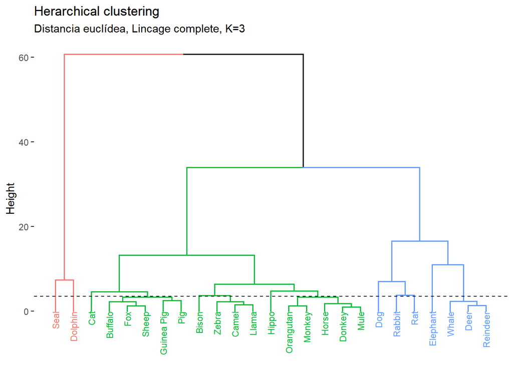

```r
fviz_dend(x = hc_euclidea_complete, k = 3, cex = 0.6) +
  geom_hline(yintercept = 3.5, linetype = "dashed") +
  labs(title = "Herarchical clustering",
       subtitle = "Distancia euclídea, Lincage complete, K=3")
```

### 2. Realice un Kmeans, cual es el mejor K para este problema?

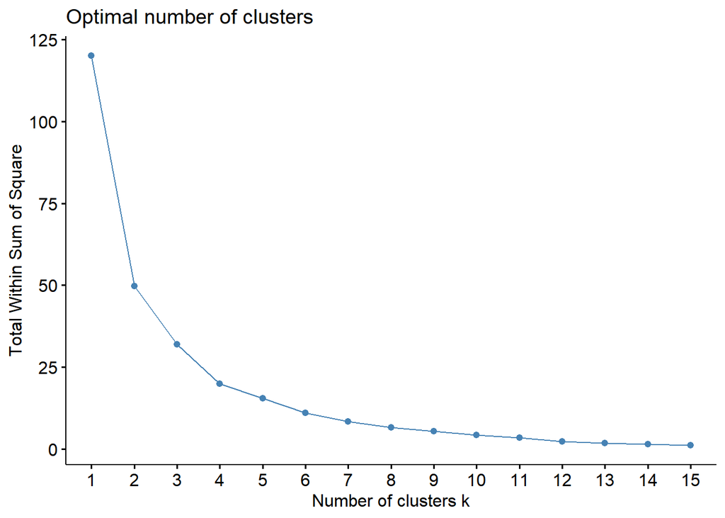

```r
mammals_new_scale <- scale(mammals_new)
fviz_nbclust(x = mammals_new_scale, FUNcluster = kmeans, method = "wss", k.max = 15,
             diss = get_dist(mammals_new_scale, method = "euclidean"), nstart = 50)
```

### 3. Interprete los grupos.

```r
set.seed(123)
km.clusters <- kmeans(x = mammals_new_scale, centers = 3, nstart = 50)
which(km.clusters$cluster == 3)
```

```
##    Seal Dolphin
##      24      25
```

```
## Too few points to calculate an ellipse
```

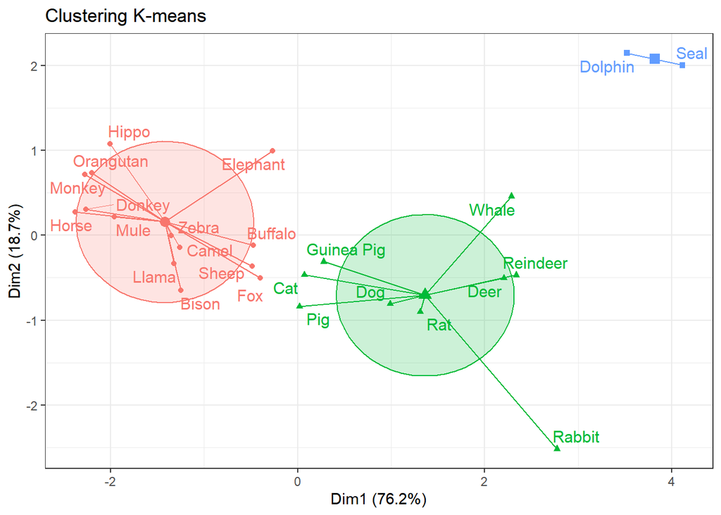

```r
fviz_cluster(object = km.clusters, data = mammals_new_scale, show.clust.cent = TRUE,
             ellipse.type = "euclid", star.plot = TRUE, repel = TRUE) +
  labs(title = "Clustering K-means") +
  theme_bw() +
  theme(legend.position = "none")
```

### Ejercicio 4 (30 puntos)

### Utilizando el dataset all.us.city.crime.1970 del paquete cluster.datasets, realice lo #### siguiente:

### 1. Realice un cluster jerárquico, cual es la altura para obtener 4 grupos?.

```r
library(cluster.datasets)
data(all.us.city.crime.1970)

all_us_city_crime <- all.us.city.crime.1970[,-1]
rownames(all_us_city_crime) <- all.us.city.crime.1970[,1]


mat.dist <- dist(x = all_us_city_crime, method = "euclidean")
DT::datatable(round(as.matrix(mat.dist), 2))
```

|  | Anaheim | Baltimore | Boston | Buffalo | Chicago | Cincinnatti | Cleveland | Dallas | Detroit | Houston | Los Angeles | Miami | Milwaukee | Minneapolis | New York | Newark | Paterson | Philadelphia | Pittsburgh | St Louis | San Francisco | San Diego | Seattle | Washington |
| --- | --- | --- | --- | --- | --- | --- | --- | --- | --- | --- | --- | --- | --- | --- | --- | --- | --- | --- | --- | --- | --- | --- | --- | --- |
| Anaheim | 0 | 1058.3 | 1572.5 | 761.05 | 5771.94 | 710.03 | 1360.98 | 422.11 | 2982.5 | 807.65 | 5749.03 | 698.26 | 1114.38 | 624.64 | 10348.5 | 732.38 | 807.09 | 3605.88 | 1357.97 | 1139.87 | 1957.93 | 606.05 | 419.2 | 1714.36 |
| Baltimore | 1058.3 | 0 | 1015.67 | 1108.33 | 5007.5 | 1089.95 | 838.96 | 723.85 | 2248.15 | 390.19 | 5040.95 | 1011.05 | 1334 | 737.12 | 9604.74 | 408.54 | 1158.14 | 2880.57 | 964.09 | 496.8 | 1372.17 | 1078.09 | 1117.36 | 849.61 |
| Boston | 1572.5 | 1015.67 | 0 | 1516.45 | 4402.47 | 1516.33 | 799.88 | 1398.73 | 1919.98 | 994.89 | 4476.04 | 1757.79 | 1573.21 | 1025.99 | 9034.81 | 1031.99 | 1501.12 | 2253.2 | 673.39 | 652.78 | 1252.97 | 1504.98 | 1679.56 | 836.9 |
| Buffalo | 761.05 | 1108.33 | 1516.45 | 0 | 5765.37 | 126.11 | 1077.86 | 808.87 | 3192.64 | 1030.5 | 5892.02 | 1136.86 | 384.13 | 602.87 | 10438 | 782.28 | 100.06 | 3553.18 | 1070.31 | 1279.57 | 2298.83 | 164.4 | 1121.53 | 1800.3 |
| Chicago | 5771.94 | 5007.5 | 4402.47 | 5765.37 | 0 | 5729.46 | 5034.93 | 5578.45 | 3069.27 | 5124.63 | 1218.82 | 5911.88 | 5729.18 | 5334.2 | 4736.55 | 5231.15 | 5764.25 | 2223.23 | 4727.11 | 4750.79 | 4172.02 | 5765.17 | 5810.7 | 4203.46 |
| Cincinnatti | 710.03 | 1089.95 | 1516.33 | 126.11 | 5729.46 | 0 | 1127.83 | 776.36 | 3151.01 | 1005.95 | 5852.43 | 1136.47 | 427 | 593.52 | 10397.92 | 762.37 | 196.07 | 3516.12 | 1056.25 | 1259.32 | 2263.73 | 146.13 | 1086.38 | 1768.27 |
| Cleveland | 1360.98 | 838.96 | 799.88 | 1077.86 | 5034.93 | 1127.83 | 0 | 1133.27 | 2537.78 | 856.44 | 5158.5 | 1416.69 | 1139.88 | 807.84 | 9686.47 | 761.39 | 1058.27 | 2887.87 | 793.61 | 794.77 | 1731.29 | 1112.63 | 1501.43 | 1187.53 |
| Dallas | 422.11 | 723.85 | 1398.73 | 808.87 | 5578.45 | 776.36 | 1133.27 | 0 | 2769.18 | 522.85 | 5556.87 | 511.69 | 1159.9 | 568.57 | 10157.68 | 472.67 | 868.19 | 3427.69 | 1250.86 | 881.78 | 1734.38 | 691.09 | 508.73 | 1445.99 |
| Detroit | 2982.5 | 2248.15 | 1919.98 | 3192.64 | 3069.27 | 3151.01 | 2537.78 | 2769.18 | 0 | 2315.38 | 2873.35 | 3007.51 | 3313.02 | 2665.89 | 7447.95 | 2494.75 | 3213.86 | 1482.29 | 2362.61 | 1987.54 | 1187.58 | 3148.97 | 2914.21 | 1456.69 |
| Houston | 807.65 | 390.19 | 994.89 | 1030.5 | 5124.63 | 1005.95 | 856.44 | 522.85 | 2315.38 | 0 | 5113.29 | 853.54 | 1301.3 | 559.53 | 9703.63 | 272.43 | 1067.84 | 2988.13 | 1003.61 | 406.23 | 1316.95 | 955.6 | 828.05 | 962.97 |

[output cut: 14 more lines]

### Verificar el árbol resultante

```r
# Matriz de distancias euclídeas
mat_dist <- dist(x = all_us_city_crime, method = "euclidean")
# Dendrogramas con linkage complete y average
hc_euclidea_complete <- hclust(d = mat_dist, method = "complete")
hc_euclidea_average  <- hclust(d = mat_dist, method = "average")
cor(x = mat_dist, cophenetic(hc_euclidea_complete))
```

```
## [1] 0.8777294
```

[figure not shown]

```r
fviz_dend(x = hc_euclidea_complete, k = 4, cex = 0.6) +
  geom_hline(yintercept = 3.5, linetype = "dashed") +
  labs(title = "Herarchical clustering",
       subtitle = "Distancia euclídea, Lincage complete, K=3")
```

### 2. Realice un Kmeans, cual es el mejor K para este problema?

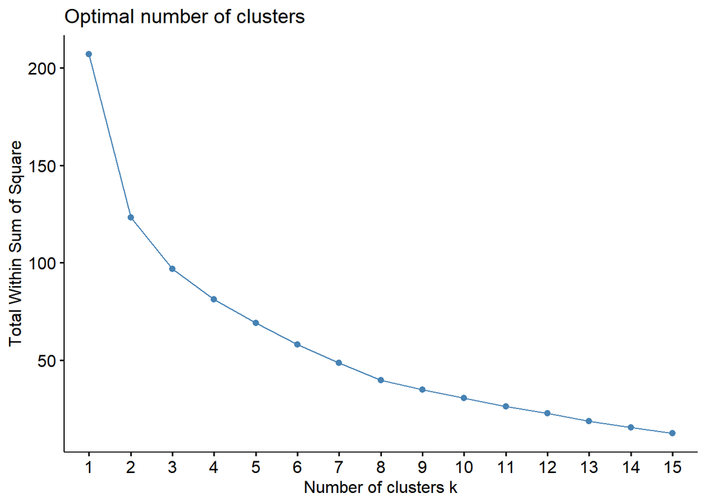

```r
all_us_crime_scale <- scale(all_us_city_crime)
fviz_nbclust(x = all_us_crime_scale, FUNcluster = kmeans, method = "wss", k.max = 15,
             diss = get_dist(all_us_crime_scale, method = "euclidean"), nstart = 50)
```

### A partir del 2 parece que se normaliza la distribución, por lo tanto en apariencia el número optimo de k es 2

```r
set.seed(123)
km.clusters <- kmeans(x = all_us_crime_scale, centers = 2, nstart = 50)
which(km.clusters$cluster == 2)
```

```
##      Anaheim       Boston      Buffalo  Cincinnatti    Milwaukee  Minneapolis
##            1            3            4            6           13           14
##     Paterson Philadelphia   Pittsburgh    San Diego      Seattle
##           17           18           19           22           23
```

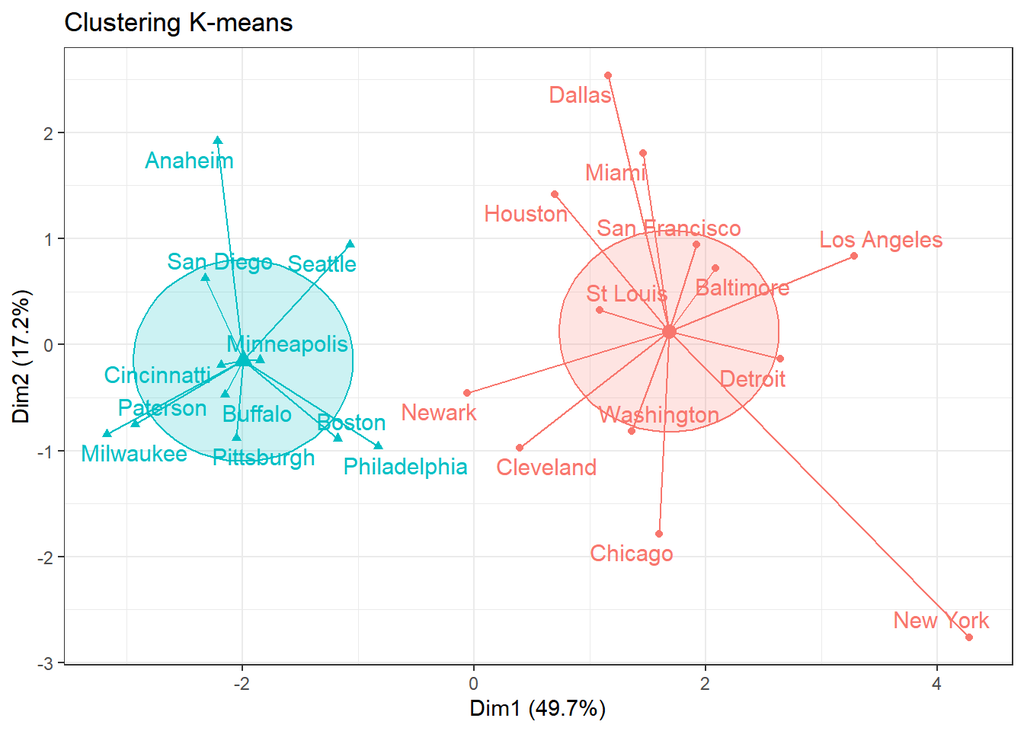

```r
fviz_cluster(object = km.clusters, data = all_us_crime_scale, show.clust.cent = TRUE,
             ellipse.type = "euclid", star.plot = TRUE, repel = TRUE) +
  labs(title = "Clustering K-means") +
  theme_bw() +
  theme(legend.position = "none")
```

### 3. Interprete los grupos.

Lo que indica las visualizaciones es que el comportamiento delictivo en las diversas ciudades se puede clusterizar a partir de k=2. Posiblemente la relación de los datos reflejada en las características de los centroides hace referencia a los crimines más comunes en las ciudades. Se puede observar que en el cluster azul, las ciudades son un poco más rurales (rural escala de USA), por lo que los crímenes ahi pueden ser de un tipo en específico y en el cluster rojo, vemos ciudades más urbanos.